# Task 1

Shimin

1/19/2021

```r
library(dplyr, quietly = TRUE)
library(descr, quietly = TRUE)
library(Hmisc, quietly = TRUE)
library(MASS, quietly = TRUE)
library(RcmdrMisc, quietly = TRUE)
library(readxl, quietly = TRUE)
library(caret, quietly = TRUE)
library(Metrics, quietly = TRUE)
library(glmnet, quietly = TRUE)
library(ggpubr)
library(moments)
#install.packages("countrycode")
library(countrycode)
```

# Data Interpretation

Y variable: CO2 emmission X variable: country, food_category, consumption Objective: Build regression model to predict carbon footprint of different type of food from various location

# Exploratory Data Analysis

Firstly, we need to check the normality of y variable. I drew the density and qqplot graph help us seeing its distribution. The result is not ideal because the data is extremely right skewed. For further confirmation, I check its normality with shapiro test. it has a very small p value and it shows that the data is no ready for buidling linear regression model yet.

|  | X | country | food_category | consumption | co2_emmission |
| --- | --- | --- | --- | --- | --- |
| 1 | 1 | Argentina | Pork | 10.51 | 37.20 |
| 2 | 2 | Argentina | Poultry | 38.66 | 41.53 |
| 3 | 3 | Argentina | Beef | 55.48 | 1712.00 |
| 4 | 4 | Argentina | Lamb & Goat | 1.56 | 54.63 |
| 5 | 5 | Argentina | Fish | 4.36 | 6.96 |
| 6 | 6 | Argentina | Eggs | 11.39 | 10.46 |

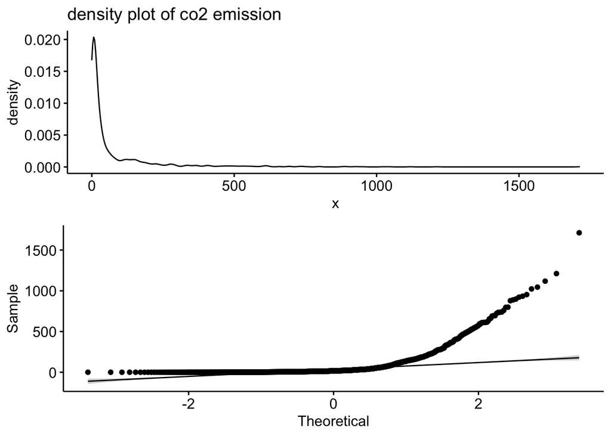

```
##
##  Shapiro-Wilk normality test
##
## data:  df$co2_emmission
## W = 0.51561, p-value < 2.2e-16
```

From Shapiro-Wilk normality test, we can see that original dataset is not normally distributed and not good for buidling linear regression model. Let’s check skewness of the the distribution of co2 emission. It shows strong positive skewness so I need to re-scale the dataset by transforming the data with log10. Here, I create a new column called “logco2” by transforming the co2emmision.

```r
skewness(df$co2_emmission,na.rm=T)
```

```
## [1] 4.001336
```

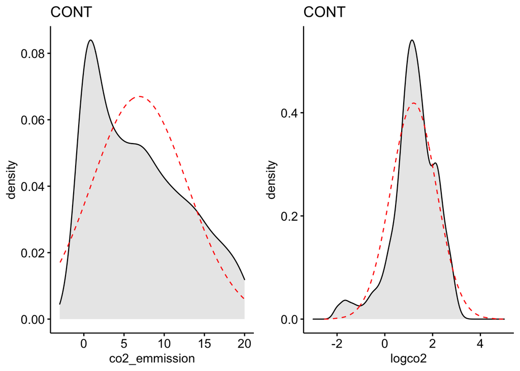

```r
df$logco2 <- log10(df$co2_emmission)

# Distribution of CO2 Emmission variable

g1 <- ggdensity(df, x = "co2_emmission", fill = "lightgray", title = "CONT") +
  scale_x_continuous(limits = c(-3, 20)) +
  stat_overlay_normal_density(color = "red", linetype = "dashed")
g2 <- ggdensity(df, x = "logco2", fill = "lightgray", title = "CONT") +
  scale_x_continuous(limits = c(-3, 5)) +
  stat_overlay_normal_density(color = "red", linetype = "dashed")
ggarrange(g1, g2, ncol = 2)
```

```r
skewness(df$co2_emmission,na.rm=T)
```

```
## [1] 4.001336
```

```r
skewness(df$logco2,na.rm=T)
```

```
## [1] NaN
```

```r
skewness(df$consumption,na.rm = T)
```

```
## [1] 3.244597
```

For further exploration, I arbitrarily fit a linear model first and check the residuals and normality of the plot. Here, I split data into two train-test sets.

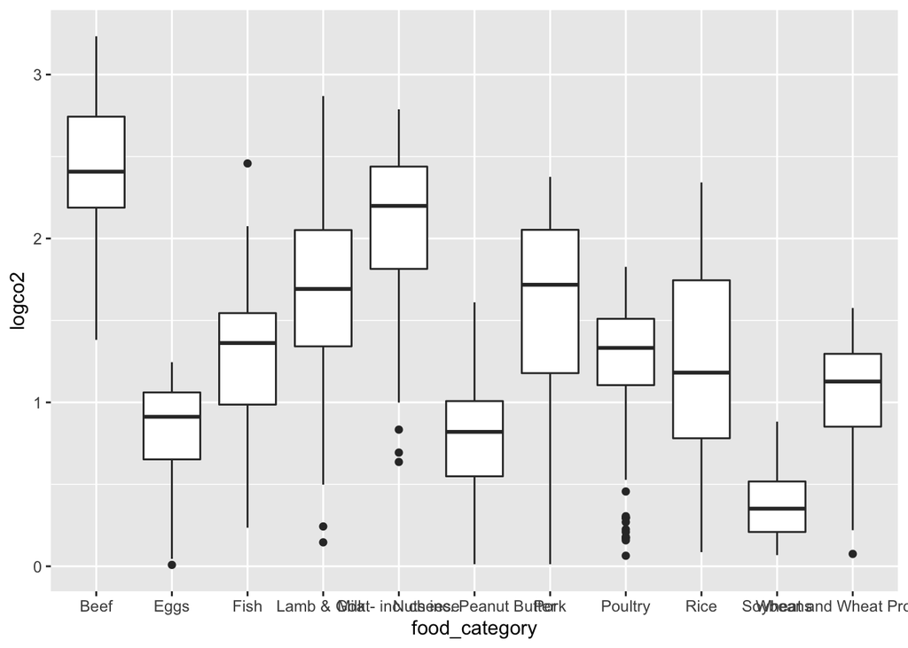

```r
df <- df %>%  filter(co2_emmission >= 1)
ggplot(df,aes(food_category,logco2))+geom_boxplot()
```

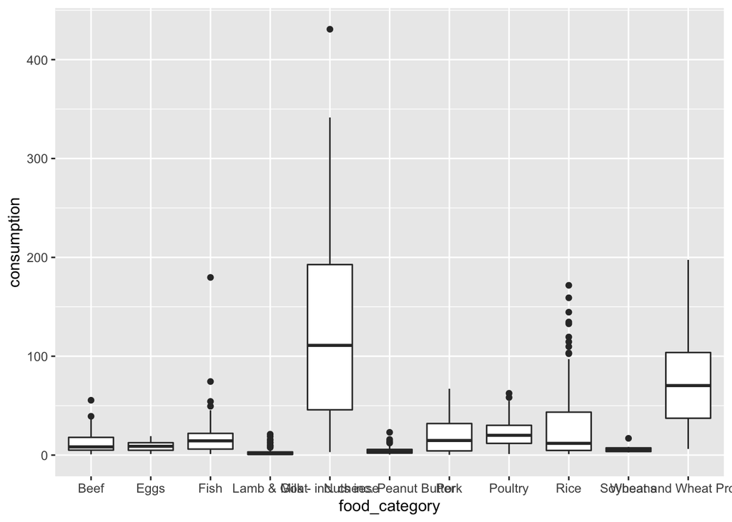

```r
ggplot(df,aes(food_category,consumption))+geom_boxplot()
```

```r
df2 <- df %>%  filter(food_category != "Milk - inc. cheese")
df2 <- df[df[,"food_category"] != "Milk - inc. cheese",]
df$code=countrycode(sourcevar = df[,"country"], origin = "country.name", destination = "continent")
str(df$code)
```

```
##  chr [1:1265] "Americas" "Americas" "Americas" "Americas" "Americas" ...
```

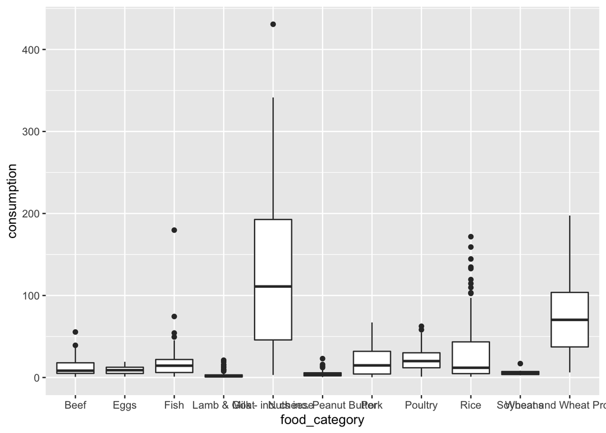

```r
df$code=as.factor(df$code)
b1 <- ggplot(df,aes(food_category,consumption))+geom_boxplot()

b2 <- ggplot(df, aes(x = food_category, y = logco2, color = code)) +
geom_boxplot(fill = NA, size = 1, method = 'gam', formula = y ~ s(x, bs = "cs")) + xlab("food category") +
ylab("log CO2 emission")
b1
```

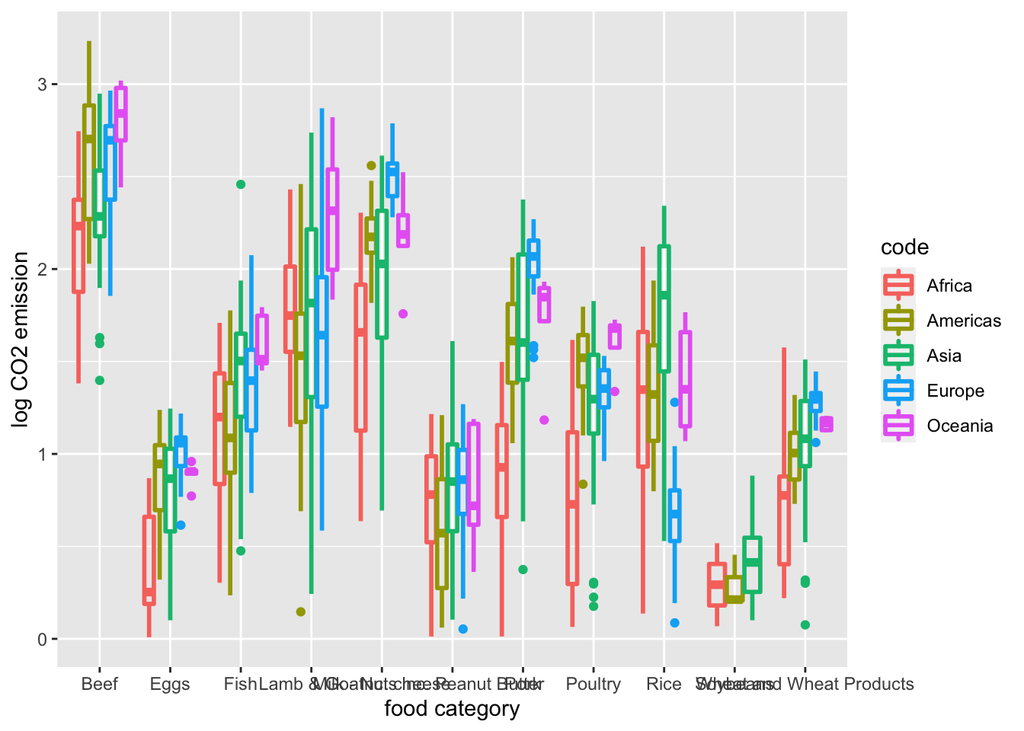

```r
b2
```

```r
# select outlier from the dataframe
mlconsump <- quantile(df[df[,"food_category"] == "Milk - inc. cheese","consumption"],probs = c(0.5,0.8,0.9,1))
df1<- df[!(df$food_category == "Milk - inc. cheese" & df$consumption>250),]

riceconsump <- quantile(df[df[,"food_category"] == "Rice","consumption"],probs = c(0.5,0.8,0.9,1))
df1 <- df[!(df[,"food_category"] == "Rice" & df$consumption>85.4),]

fishconsump <- quantile(df[df[,"food_category"] == "Fish","consumption"],probs = c(0.5,0.8,0.9,1))
df1 <- df[!(df[,"food_category"] == "Fish" & df$consumption>33.28),]
df1
```

|  | X | country | food_category | consumption | co2_emmission | logco2 | code |
| --- | --- | --- | --- | --- | --- | --- | --- |
| 1 | 1 | Argentina | Pork | 10.51 | 37.20 | 1.570542940 | Americas |
| 2 | 2 | Argentina | Poultry | 38.66 | 41.53 | 1.618361931 | Americas |
| 3 | 3 | Argentina | Beef | 55.48 | 1712.00 | 3.233503760 | Americas |
| 4 | 4 | Argentina | Lamb & Goat | 1.56 | 54.63 | 1.737431201 | Americas |
| 5 | 5 | Argentina | Fish | 4.36 | 6.96 | 0.842609240 | Americas |
| 6 | 6 | Argentina | Eggs | 11.39 | 10.46 | 1.019531685 | Americas |
| 7 | 7 | Argentina | Milk - inc. cheese | 195.08 | 277.87 | 2.443841661 | Americas |
| 8 | 8 | Argentina | Wheat and Wheat Products | 103.11 | 19.66 | 1.293583513 | Americas |
| 9 | 9 | Argentina | Rice | 8.77 | 11.22 | 1.049992857 | Americas |
| 10 | 12 | Australia | Pork | 24.14 | 85.44 | 1.931661240 | Oceania |

[output cut: 1242 more lines]

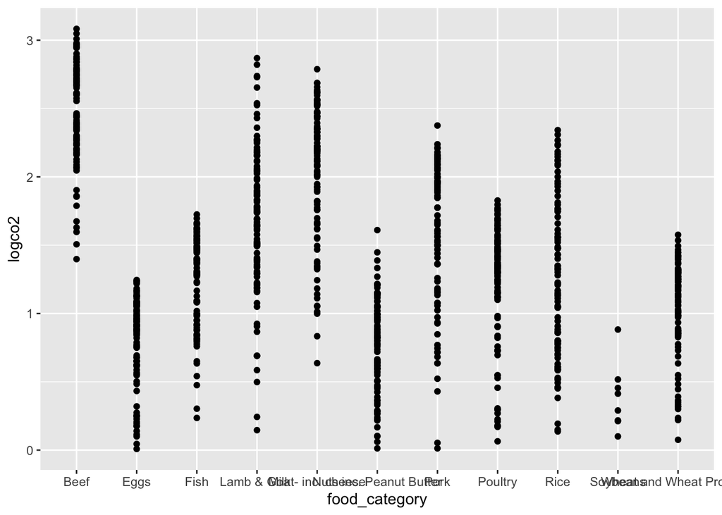

```r
# Split the data into training and test set
set.seed(123)
training.samples <- df1$logco2 %>%
  createDataPartition(p = 0.8, list = FALSE)
train.data  <- df1[training.samples, ]
test.data <- df1[-training.samples, ]
# Visualize plot of logco2 emmission vs consumption
g3 <- ggplot(train.data, aes( food_category,logco2) ) +
  geom_point()
g4 <- ggplot(train.data, aes( consumption,logco2) ) +
  geom_point() +
  stat_smooth()
g3
```

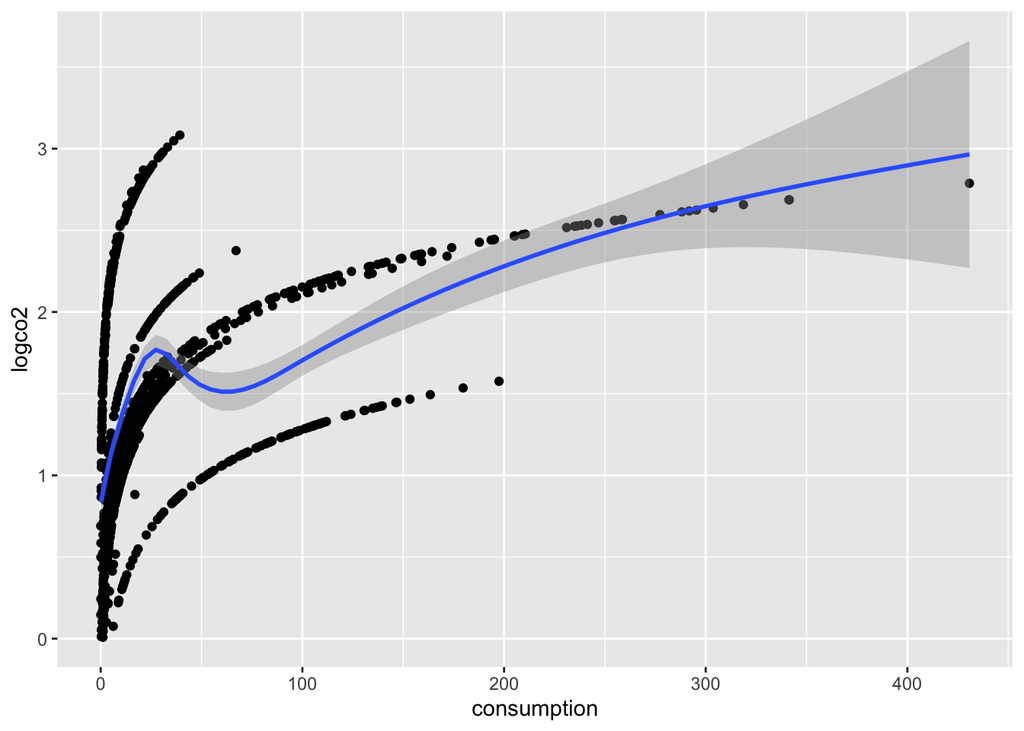

```r
g4
```

```r
# Build the model
fit <- lm(logco2~code+factor(food_category)+consumption, data=train.data)
summary(fit)
```

```
##
## Call:
## lm(formula = logco2 ~ code + factor(food_category) + consumption,
##     data = train.data)
##
## Residuals:
##      Min       1Q   Median       3Q      Max
## -1.57564 -0.17825  0.05458  0.22466  1.02134
##
## Coefficients:
##                                                 Estimate Std. Error t value
## (Intercept)                                    2.2165482  0.0391812  56.572
## codeAmericas                                   0.1996136  0.0323730   6.166
## codeAsia                                       0.1750971  0.0315986   5.541
## codeEurope                                     0.1844915  0.0317869   5.804
## codeOceania                                    0.3502027  0.0619957   5.649
## factor(food_category)Eggs                     -1.6202268  0.0480698 -33.706
## factor(food_category)Fish                     -1.2309579  0.0499726 -24.633
## factor(food_category)Lamb & Goat              -0.6946591  0.0478973 -14.503
## factor(food_category)Milk - inc. cheese       -1.1331064  0.0580146 -19.531
## factor(food_category)Nuts inc. Peanut Butter  -1.6142795  0.0477580 -33.801
## factor(food_category)Pork                     -0.9249648  0.0495840 -18.654
## factor(food_category)Poultry                  -1.2956094  0.0475510 -27.247
## factor(food_category)Rice                     -1.3080385  0.0485606 -26.936
## factor(food_category)Soybeans                 -2.0323240  0.1254565 -16.199
## factor(food_category)Wheat and Wheat Products -1.8211415  0.0508061 -35.845
## consumption                                    0.0066897  0.0003056  21.892
##                                               Pr(>|t|)
## (Intercept)                                    < 2e-16 ***
## codeAmericas                                  1.02e-09 ***
## codeAsia                                      3.85e-08 ***
## codeEurope                                    8.72e-09 ***
## codeOceania                                   2.11e-08 ***
## factor(food_category)Eggs                      < 2e-16 ***
## factor(food_category)Fish                      < 2e-16 ***
## factor(food_category)Lamb & Goat               < 2e-16 ***
## factor(food_category)Milk - inc. cheese        < 2e-16 ***
## factor(food_category)Nuts inc. Peanut Butter   < 2e-16 ***
## factor(food_category)Pork                      < 2e-16 ***
## factor(food_category)Poultry                   < 2e-16 ***
## factor(food_category)Rice                      < 2e-16 ***
## factor(food_category)Soybeans                  < 2e-16 ***
## factor(food_category)Wheat and Wheat Products  < 2e-16 ***
## consumption                                    < 2e-16 ***
## ---
## Signif. codes:  0 '***' 0.001 '**' 0.01 '*' 0.05 '.' 0.1 ' ' 1
##
## Residual standard error: 0.3404 on 988 degrees of freedom
## Multiple R-squared:  0.7523, Adjusted R-squared:  0.7485
## F-statistic:   200 on 15 and 988 DF,  p-value: < 2.2e-16
```

```r
# Make predictions
pred <- fit %>% predict(test.data)
# Model performance
MAE(pred,test.data$logco2)
```

```
## [1] 0.2611176
```

```r
RMSE(pred,test.data$logco2)
```

```
## [1] 0.3395183
```

```r
R2(pred,test.data$logco2)
```

```
## [1] 0.7552894
```

```r
AIC(fit)
```

```
## [1] 703.3704
```

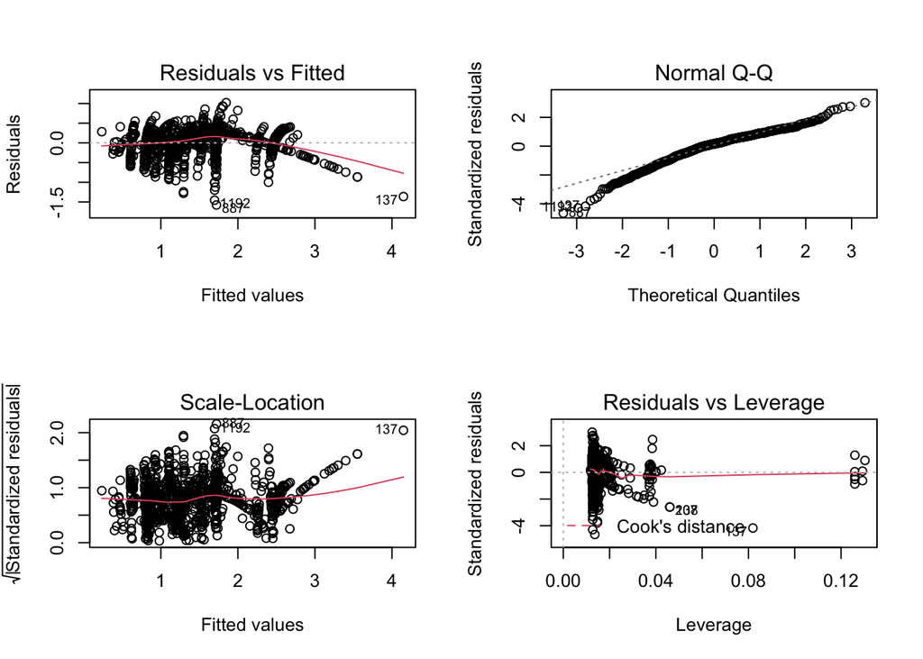

```r
# normality check
par(mfrow = c(2, 2))
plot(fit)
```

```r
quantile(fit$residuals)
```

```
##          0%         25%         50%         75%        100%
## -1.57564228 -0.17825139  0.05457915  0.22465846  1.02134126
```

```r
shapiro.test(fit$residuals)
```

```
##
##  Shapiro-Wilk normality test
##
## data:  fit$residuals
## W = 0.9579, p-value < 2.2e-16
```

```r
# Build the model2
fit2 <- lm(logco2~code+factor(food_category)+consumption+food_category*code, data=train.data)
summary(fit2)
```

```
##
## Call:
## lm(formula = logco2 ~ code + factor(food_category) + consumption +
##     food_category * code, data = train.data)
##
## Residuals:
##      Min       1Q   Median       3Q      Max
## -1.38542 -0.13681  0.03199  0.16291  1.05129
##
## Coefficients: (12 not defined because of singularities)
##                                                      Estimate Std. Error
## (Intercept)                                         2.1662788  0.0620757
## codeAmericas                                        0.3108848  0.0887949
## codeAsia                                            0.0955864  0.0851598
## codeEurope                                          0.2996656  0.0852044
## codeOceania                                         0.4193478  0.1612249
## factor(food_category)Eggs                          -1.7976836  0.0909576
## factor(food_category)Fish                          -1.1458582  0.0877347
## factor(food_category)Lamb & Goat                   -0.3876326  0.0868158
## factor(food_category)Milk - inc. cheese            -0.9598607  0.0867494
## factor(food_category)Nuts inc. Peanut Butter       -1.4823422  0.0851583
## factor(food_category)Pork                          -1.3738391  0.0922334
## factor(food_category)Poultry                       -1.4529384  0.0859549
## factor(food_category)Rice                          -1.0911320  0.0849506
## factor(food_category)Soybeans                      -1.7063544  0.3038704
## factor(food_category)Wheat and Wheat Products      -1.8088152  0.0908836
## consumption                                         0.0078454  0.0003731
## food_categoryEggs                                          NA         NA
## food_categoryFish                                          NA         NA
## food_categoryLamb & Goat                                   NA         NA
## food_categoryMilk - inc. cheese                            NA         NA
## food_categoryNuts inc. Peanut Butter                       NA         NA
## food_categoryPork                                          NA         NA
## food_categoryPoultry                                       NA         NA
## food_categoryRice                                          NA         NA
## food_categorySoybeans                                      NA         NA
## food_categoryWheat and Wheat Products                      NA         NA
## codeAmericas:food_categoryEggs                      0.1361402  0.1270585
## codeAsia:food_categoryEggs                          0.2640637  0.1245923
## codeEurope:food_categoryEggs                        0.2534909  0.1205398
```

[output cut: 95 more lines]

```
## codeOceania:food_categoryRice                       -1.139 0.255075
## codeAmericas:food_categorySoybeans                  -1.270 0.204291
## codeAsia:food_categorySoybeans                      -0.675 0.499925
## codeEurope:food_categorySoybeans                        NA       NA
## codeOceania:food_categorySoybeans                       NA       NA
## codeAmericas:food_categoryWheat and Wheat Products  -0.905 0.365764
## codeAsia:food_categoryWheat and Wheat Products      -0.011 0.991503
## codeEurope:food_categoryWheat and Wheat Products    -1.527 0.127130
## codeOceania:food_categoryWheat and Wheat Products   -0.978 0.328412
## ---
## Signif. codes:  0 '***' 0.001 '**' 0.01 '*' 0.05 '.' 0.1 ' ' 1
##
## Residual standard error: 0.2975 on 950 degrees of freedom
## Multiple R-squared:  0.8181, Adjusted R-squared:  0.808
## F-statistic: 80.62 on 53 and 950 DF,  p-value: < 2.2e-16
```